# pitch - capstone next word app

09 June 2021

## Table of content

- Motivation
- udpipe for annotation and cleaning
- udpipe for n-grams
- basic algorithm
- using the app
- final thoughs

## Motivtion to next word app

This App demonstrates the approach using n-grams to predict the next word. A possible application is the auto completion while editing. You can find this application for instance in

- web browser
- google doc

which works here pretty well especially in google docs. The quick response predicting the next word in google docs is fascinating.

In the poc text from three different sources (twitter, blomberg, blogs) is used to build a model which predicts the next word after an input of a phrase. The basic algorith uses n-grams (uni, bi and tri) and a markov chain approach for probability assumptions. Problematic is the size of the underlying n-gram which ca be huge if many documents are considered.

## udpipe for annotation and cleaning

For the poc I finally end up with [udpipe](https://bnosac.github.io/udpipe/docs/doc1.html) package for tokenizing and cleaning the docs provided by swiftkey. Before tokenizing the language model dl.model.file is loaded by

```r
  dl <- udpipe_download_model(language = "english")
  dl.model.file <- dl$file_model
```

than the text can be tokenize by

```r
annotation_en <- udpipe(docs$text, dl.model.file)
```

and be drop symbols, particle, and punctuation by filter upos (Universal part-of-speech)

```r
  annotation_en %>% filter(! (upos %in%  c("PUNCT","SYM", "PART")) )
```

## udpipe for n-grams

The n-grams are calculated by udpipes’ txt_nextgram() function applied from annotated and tokenized text. Lemma words which are kind of stem of each word are used to have a more general model. This filtering and annotation is performed also for the input text in the app of course.

```r
trigram_df <-
  annotation_en %>%
  filter(! (upos %in%  c("PUNCT","SYM", "PART")) ) %>%
  group_by(chunk_id, doc_id, paragraph_id, sentence_id) %>%
  summarise( ngram = txt_nextgram(lemma, n = 3, sep = ";" )) %>%
  separate(ngram, c("word1", "word2", "word3"), sep = ";") %>%
  ungroup() %>%
  filter(!is.na(word1) & !is.na(word2) & !is.na(word3) ) %>%
  group_by(word1, word2, word3) %>%
  summarise(freq=n())
```

## basic algorithm

For the basic algorithm [Katz back-off model](https://en.wikipedia.org/wiki/Katz%27s_back-off_model) it turns out that the bottle neck in the performance is searching for bi-grams within the tr-grams. The bi-gram of interest is the combination of the last two words (lemmas) of the input phrase. In the nextWord app the bi-grams and tri-grams are saved as data.frame tables with the words splitted in different columns. This approach is 3 times faster than searching for bi-grams in tri-grams using regular expression.

## using the app

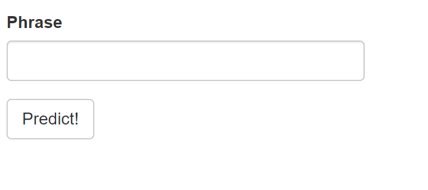

Just write the phrase in the input text field and press predict.

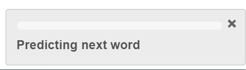

On the right botton corner appears progess bar while calculate the next best word.

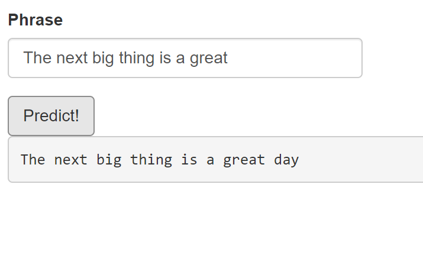

At the end you will see the phrase with the predicted next word below the predict button.

## final thoughs

The performace in repsonse and considering more sentences seems really a cutting edge problem. Probably one need to consider a tree or graph based data model to achieve better performance and response at the same time. To put a bi-gram into a graph is clear but how two include a tri-gram into a graph model which can be queried for bi-grams it was not resolved yet. So please reach out if you have an idea.

## Project Reproducible Pitch URLs

You can find all details for the project in the below Documentation

- next word prediction app source: https://github.com/philipus/nextword-app
- pitch deck source: https://github.com/philipus/philipus.github.io/blob/main/pitch_nextword.html
- pitch deck url: https://philipus.github.io/pitch_nextword.html